# A simple tutorial using SpatialQPFs library to extract spatial features based on cell level data from images

Xiao Li xiao.li.xl2@roche.com

2024-11-18

# Introduction

This Rmarkdown file provides a simple tutorial on how to use the functions in SpatialQPFs R library to calculate the features to decipher spatial relationship between different cell types, from spatial statistics perspective.

# How to use the functions in SpatialQPFs

Firstly, let’s simulate a synthetic dataset to begin with. In reality, to extract detailed cell-level information, users must preprocess the digital image. This preprocessing step involves isolating key information such as cell coordinates and cell identity from a variety of digital slides, which can encompass images stained with H$\&$E, Immunohistochemistry, or Immunofluorescence techniques, as well as spatially resolved single-cell imaging.

```r
library('SpatialQPFs')

set.seed(42)

# n = 2000
# dat = rbind(
#       data.frame("x" = round(runif(n = n, min = 1, max = 10000)),
#                  "y" = round(runif(n = n, min = 1, max = 10000)),
#                  "cell_id" = c("TC", "Lym")[rbinom(n = n, size = 1, prob = c(0.8, 0.2)) + 1]),
#       data.frame("x" = round(runif(n = 100, min = 1500, max = 5000)),
#                  "y" = round(runif(n = 100, min = 1500, max = 5000)),
#                  "cell_id" = c("TC", "Lym")[rbinom(n = n, size = 1, prob = c(0.1, 0.9)) + 1])
# )
#
# write.csv(dat, '/Users/lix233/SpatialQPFs/inst/extdata/dat.csv', row.names = F)

dat = read.csv(system.file("extdata", "dat.csv", package = "SpatialQPFs"))


cat("The first 20 cell in the example csv file looks like:")
```

```
## The first 20 cell in the example csv file looks like:
```

```r
dat[1:20,]
```

```
##       x    y cell_id
## 1  9148 9900     Lym
## 2  9371 4385     Lym
## 3  2862 6999     Lym
## 4  8305 8891     Lym
## 5  6418 8342     Lym
## 6  5191 7344      TC
## 7  7366 6469     Lym
## 8  1348 8429      TC
## 9  6570 1597     Lym
## 10 7051 3638     Lym
## 11 4578 2752     Lym
## 12 7191 1249      TC
## 13 9347 5657     Lym
## 14 2555 6733      TC
## 15 4623   18     Lym
## 16 9400 8009      TC
## 17 9782 1983     Lym
## 18 1176 6668     Lym
## 19 4750 7878     Lym
## 20 5604 9522      TC
```

## Visualization of the raw cell data and its spatial density plot

Now we have the generated the data, we want to visualize the cell data, this can be done by calling `Data_Vis()` function.

- noticed, the “x_var”, “y_xar” and “cell_class_var” argument in the functions are the column names that indicting cell position x, y and its cell type, e.g. lymphoctye or tumor-cell, etc.
- “cell_type” argument indicates which cell type the user wants to visualize.

We look at “Lym” cell type first:

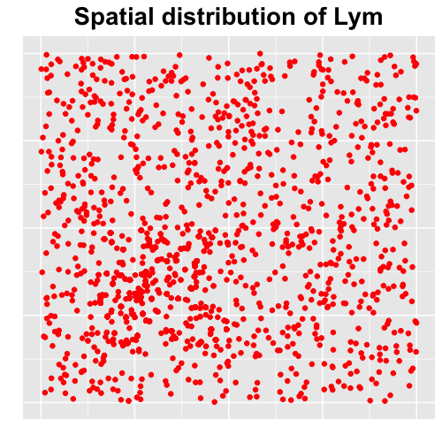

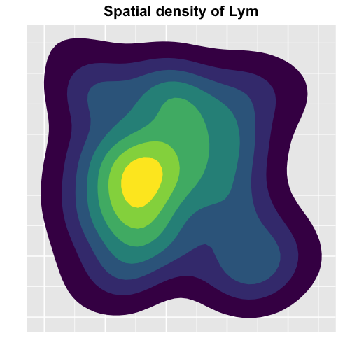

```r
path = gsub("dat.csv", "", system.file("extdata", "dat.csv", package = "SpatialQPFs"))
# print(paste0("Your file path is: ", path))
file = "dat.csv"

Data_Vis(path = path, file = file, cell_class_var = "cell_id", x_var = "x", y_var = "y", cell_type = "Lym")
```

Next, “TC” cell type:

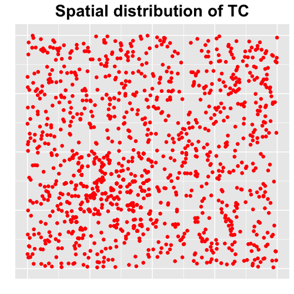

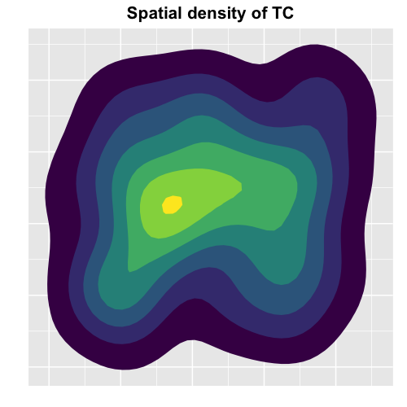

```r
Data_Vis(path = path, file = file, cell_class_var = "cell_id", x_var = "x", y_var = "y", cell_type = "TC")
```

## Point pattern data analysis

To utilize spatial point process methods, SpatialQPFs provides 3 functions:

- for a single cell type, one can use `Point_pattern_data_uni()`
- for a pair of cell types, one can call `Point_pattern_data_bi()` and `Point_pattern_data_ITLR()`. For details of the functions, refer to `help(Point_pattern_data_uni)`, `help(Point_pattern_data_bi)`, and `help(Point_pattern_data_ITLR)`

For “Lym” cell type spatial features:

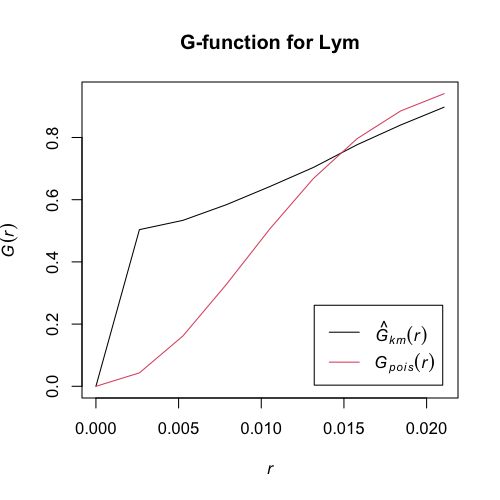

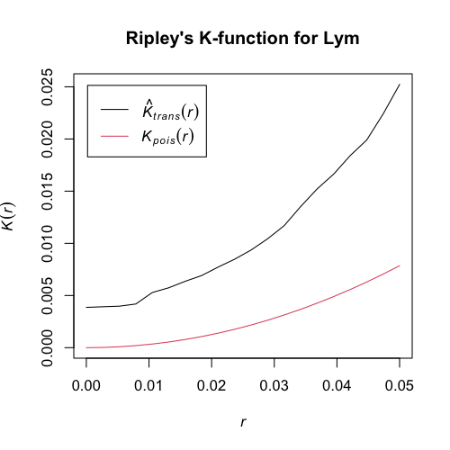

```r
ss_point_uni_lym = Point_pattern_data_uni(path = path, file = file, x_var = "x", y_var = "y", cell_class_var = "cell_id", cell_type = "Lym", scale = 500, myplot = T)
```

```r
print(ss_point_uni_lym)
```

```
## $g_AUC
## [1] 0.002608665
##
## $g_r
## [1] 0.04474579
##
## $k_AUC
## [1] 0.000407792
##
## $k_vals_med
##         50%
## 0.008925861
##
## $k_vals_q1
##         25%
## 0.005627687
##
## $k_vals_q3
##        75%
## 0.01557522
##
## $k_vals_max
## [1] 0.02523923
##
## $CE
##     naive
## 0.7097989
```

For “TC” cell type spatial features:

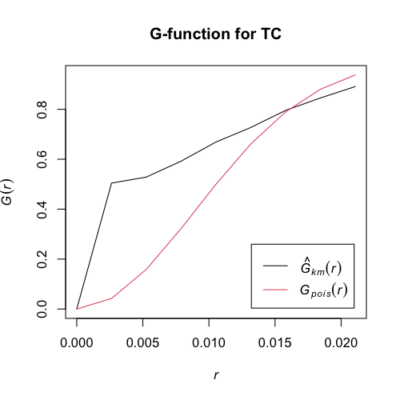

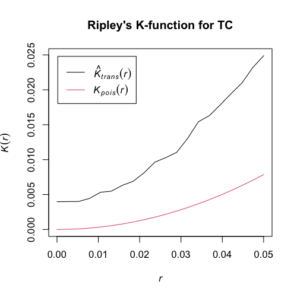

```r
ss_point_uni_TC = Point_pattern_data_uni(path = path, file = file, x_var = "x", y_var = "y", cell_class_var = "cell_id", cell_type = "TC", scale = 500, myplot = T)
```

```r
print(ss_point_uni_TC)
```

```
## $g_AUC
## [1] 0.002945771
##
## $g_r
## [1] 0.04476818
##
## $k_AUC
## [1] 0.0004383003
##
## $k_vals_med
##         50%
## 0.009968881
##
## $k_vals_q1
##         25%
## 0.005447047
##
## $k_vals_q3
##       75%
## 0.0166862
##
## $k_vals_max
## [1] 0.02489451
##
## $CE
##     naive
## 0.6902926
```

For spatial interaction features between “TC” and “Lym”:

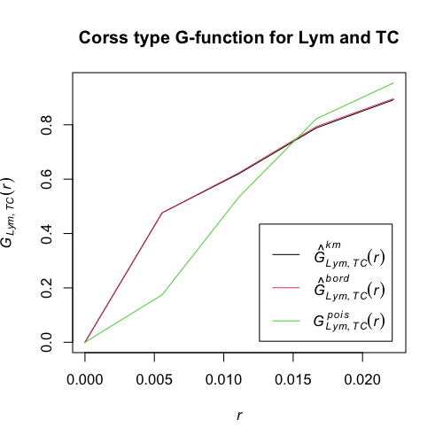

```
## Cross type G-function is calculated.
```

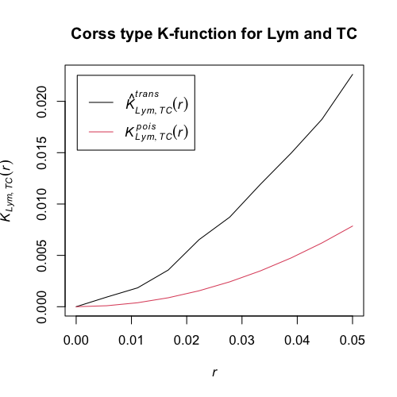

```
## Cross type K-function is calculated.
## 1,
## 2.
```

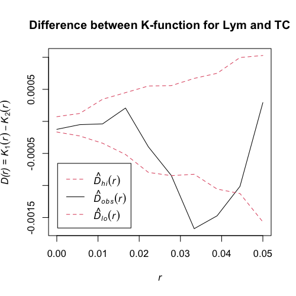

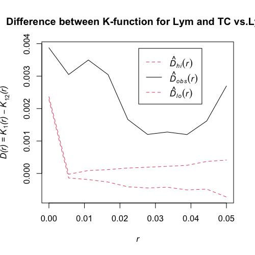

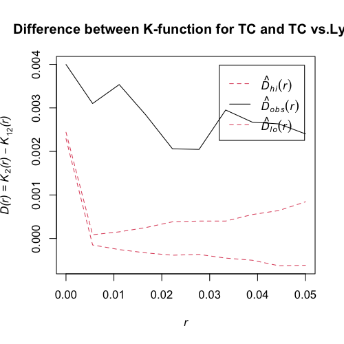

```
## Differences in Ripley's K-function is calculated.
```

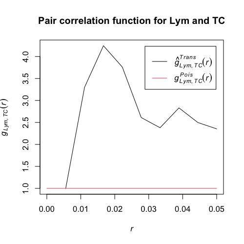

```
## Pair correlation function is calculated.
```

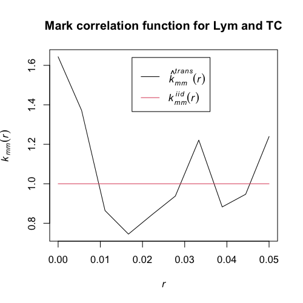

```
## Mark correlation function is calculated.
```

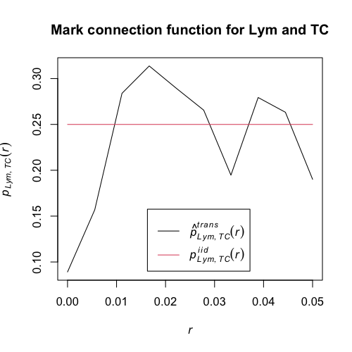

```
## Mark connection function is calculated.
```

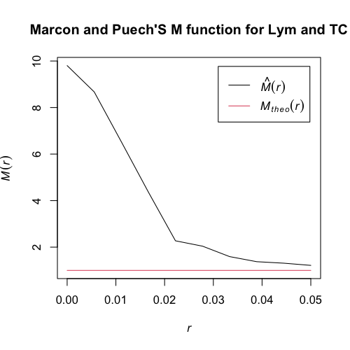

```
## Marcon and Puech's M function is calculated.
```

```r
ss_point_bi = Point_pattern_data_bi(path = path,
                                    file = file, x_var = "x", y_var = "y", cell_class_var = "cell_id",
                                    from_type = "Lym",
                                    to_type = "TC",
                                    scale = 500, myplot = T)
```

```r
print(ss_point_bi)
```

```
## $g_cross_AUC
## [1] 0.001359353
##
## $g_cross_r
## [1] 0.04445334
##
## $k_cross_AUC
## [1] 0.0003018984
##
## $k_cross_vals_med
##         50%
## 0.007625776
##
## $k_cross_vals_q1
##         25%
## 0.002272805
##
## $k_cross_vals_q3
##        75%
## 0.01420104
##
## $k_cross_vals_max
## [1] 0.02262218
##
## $K12_Diff_AUC
## [1] -2.888522e-05
##
## $k_k1k2_vals_med
##           50%
## -0.0002606136
##
## $k_k1k2_vals_q1
##           25%
## -0.0009708354
##
## $k_k1k2_vals_q3
##           75%
## -4.197294e-05
##
## $k_k1k2_vals_max
```

[output cut: 118 more lines]

```
##      25%
## 1.429604
##
## $M_vals_q3
##      75%
## 5.988474
##
## $M_vals_max
## [1] 9.802432
##
## $M_vals_min
## [1] 1.216099
##
## $M_r
## [1] 0
```

```
## Xrange is  1 4995
## Yrange is  16 4988
## Doing quartic kernel
```

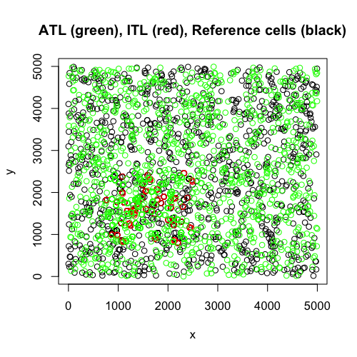

```r
ss_point_ITLR = Point_pattern_data_ITLR(path = path,
                                        file = file, x_var = "x", y_var = "y", cell_class_var = "cell_id",
                                        from_type = "Lym",
                                        to_type = "TC",
                                        micron_per_pixel = 0.5,
                                        myplot = T)
```

```r
print(ss_point_ITLR)
```

```
## $ITLR
## [1] 0.09045971
##
## $ITLR2
## [1] 0.09256449
```

## Areal data

To utilize spatial lattice process methods, SpatialQPFs provides `Areal_data()` function. For details of the function, refer to `help(Areal_data)`

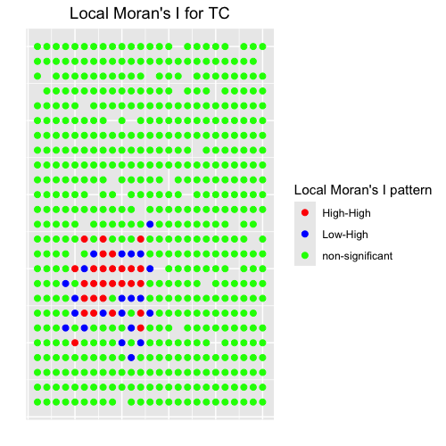

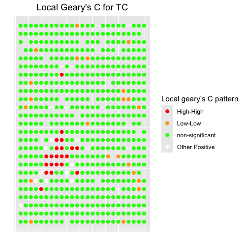

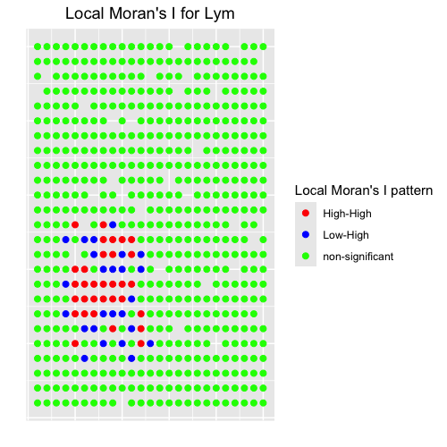

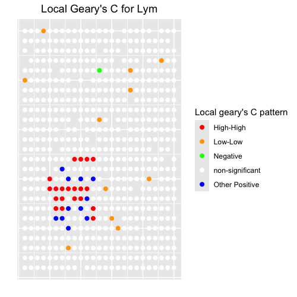

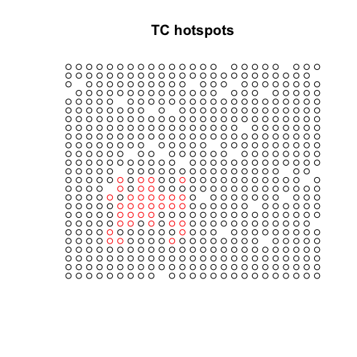

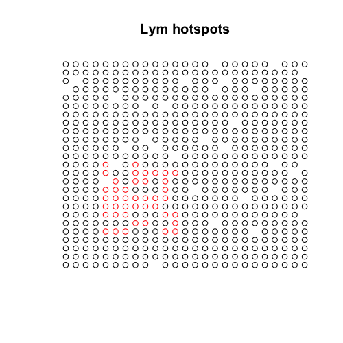

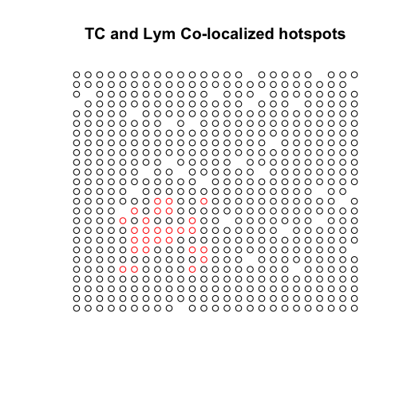

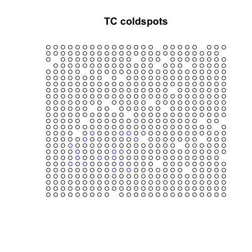

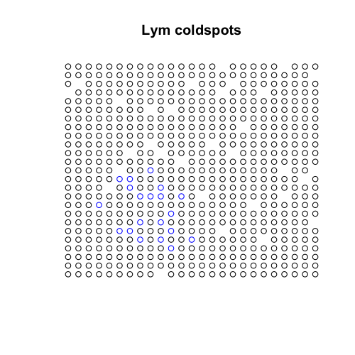

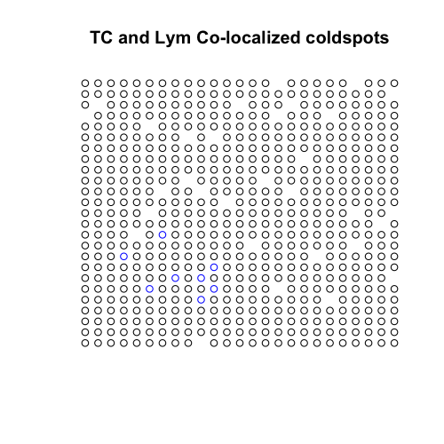

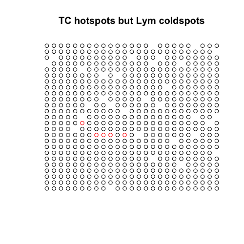

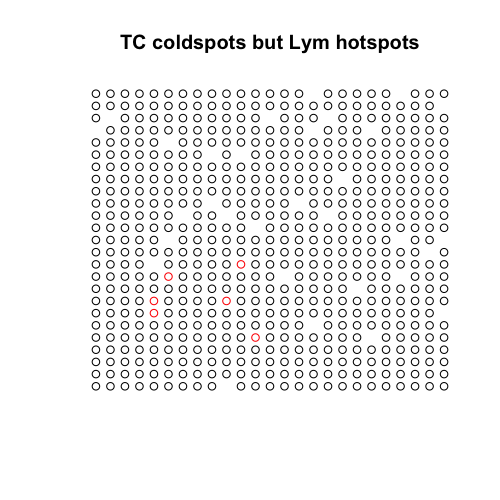

[2 more figures not shown]

```
## Areal features are calculated.
```

```r
ss_lattice_bi = Areal_data(path = path, file = file,
                           x_var = "x", y_var = "y", cell_class_var = "cell_id",
                           from_type = "Lym",
                           to_type = "TC",
                           scale = 200,
                           myplot = T)
```

```r
print(ss_lattice_bi)
```

```
## $BC
## [1] 0.7902325
##
## $MH_index
## [1] 0.6479746
##
## $JaccardJ
## [1] 0.4027345
##
## $SorensenL
## [1] 0.5742134
##
## $Moran_I_tumor
## [1] 0.3417653
##
## $Moran_I_immune
## [1] 0.3630319
##
## $moran_I_Bivariate
## [1] 0.3551931
##
## $geary_TC
## [1] 0.7261855
##
## $geary_IC
## [1] 0.7040808
##
## $moran_HL_TC
## [1] 0
##
## $moran_HH_TC
## [1] 0.04713805
##
## $moran_LH_TC
## [1] 0.03703704
##
## $moran_LL_TC
## [1] 0
##
## $geary_HH_TC
```

[output cut: 64 more lines]

```
##
## $Lee_LL_TC_IC
## [1] 0.005050505
##
## $Lee_HL_IC_TC
## [1] 0.003367003
##
## $Lee_HH_IC_TC
## [1] 0.04208754
##
## $Lee_LH_IC_TC
## [1] 0.03030303
##
## $Lee_LL_IC_TC
## [1] 0.001683502
```